# GAM_all_variables_different_outcomes

# Research question

How did neonatal health evolve through time (2007-2020)?

Particularly, did it change during two important crisis: the 2009 economic crisis and the current COVID-19 pandemic?

We focus on the evolution of birthweight and gestational age, and on the rates of stillbirth, preterm birth, lowbirth weight and macrosomia babies.

COVID data will be included soon: hospital cases, mortality. Temperature will also maybe be included.

# Data and Methods

## Data

We used data from the Federal Office of Statistics: Bevnat. It covers:

- All births that occurred in Switzerland
- Between 1987 and 2021

## Variables

### Swiss-SEP

Average Swiss neighbourhood index of socioeconomic position (Swiss-SEP 2.0). Swiss-SEP 2.0 indicates the average socioeconomic situation in a municipality. It was developed by the Institute for Social and Preventive Medicine at the University of Bern.

## Exclusions steps

- As gestational age was only recorded systematically from 2007, we analysed data from this year only
- Steps of exclusions: see the ppt

Definitions:

- Preterm birth babies : <37 weeks
- Low birthweight babies : <2500g
- Macrosomia babies: >= 4000g
- “normal” birthweight babies: )2500-4000)

We work with two different datasets:

- one that includes stillbirth cases to investigate stillbirth outcome: bevn_eco_in6.
- one that excludes stillbirth cases to investigate birthweight/gestational age/ preterm birth/ low birth weight/ macrosomia outcomes : bevn_eco_in7.

## Characteristics at inclusion and in two other datasets used

- see tables in html.

## Methods

We built different GAM models, investigating the following outcomes:

- birthweight as a continuous variable
- stillbirth : binary yes/no variable
- gestational age: as a continuous variable, in days
- preterm birth: binary yes/no variable.
- low birthweight: binary yes/no variable, comparing LBW babies vs the rest
- low birthweight: binary yes/no variable, comparing LBW babies vs “normal” birthweight babies
- macrosomia: binary yes/no variable, comparing macrosomia babies vs “normal” birthweight babies

# Birthweight

We chose this model based on lower AIC and also lower k value for maternal age, which seems more appropriate when looking at the graph.

```
##
## Family: gaussian
## Link function: identity
##
## Formula:
## BW ~ s(GA_weeks) + s(mat_age) + s(birth_Y_M_num) + s(month, bs = "cc") +
##     s(mean_ssep2) + s(mean_Alt_mean2) + parity_cat + sex + Urban3 +
##     Language + mother_nationality_cat2 + civil_status3 + HW +
##     GR + COVID_first_wave + COVID_second_wave
##
## Parametric coefficients:
##                                                      Estimate Std. Error  t value
## (Intercept)                                         3345.7091     0.8514 3929.489
## parity_cat(1,2]                                      123.2307     0.8114  151.877
## parity_cat(2,3]                                      167.8745     1.2387  135.527
## parity_cat(3,20]                                     193.7923     2.1381   90.637
## sex2                                                -146.8695     0.7178 -204.606
## Urban3                                                -1.8230     0.7721   -2.361
## LanguageFrench                                       -44.0613     0.9018  -48.858
## LanguageItalian                                      -69.4542     2.0813  -33.371
## mother_nationality_cat2Africa                          9.0217     2.1836    4.132
## mother_nationality_cat2Asia                          -25.4757     1.9842  -12.839
## mother_nationality_cat2Europe                         28.8037     0.8231   34.994
## mother_nationality_cat2Northern America               58.6140     4.7014   12.467
## mother_nationality_cat2Southern and Central America   40.3977     2.7120   14.896
## civil_status3Single                                  -33.2543     0.8954  -37.141
## HW1                                                   -2.7945     3.3618   -0.831
## GR1                                                    2.0800     2.5235    0.824
## COVID_first_wave1                                     -1.8167     3.6448   -0.498
## COVID_second_wave1                                     3.0197     3.0573    0.988
##                                                     Pr(>|t|)
## (Intercept)                                          < 2e-16 ***
## parity_cat(1,2]                                      < 2e-16 ***
## parity_cat(2,3]                                      < 2e-16 ***
## parity_cat(3,20]                                     < 2e-16 ***
## sex2                                                 < 2e-16 ***
## Urban3                                                0.0182 *
## LanguageFrench                                       < 2e-16 ***
## LanguageItalian                                      < 2e-16 ***
## mother_nationality_cat2Africa                        3.6e-05 ***
```

[output cut: 10 more lines]

```
## Signif. codes:  0 '***' 0.001 '**' 0.01 '*' 0.05 '.' 0.1 ' ' 1
##
## Approximate significance of smooth terms:
##                     edf Ref.df         F p-value
## s(GA_weeks)       8.875  8.992 81491.255 < 2e-16 ***
## s(mat_age)        5.313  6.275    14.178 < 2e-16 ***
## s(birth_Y_M_num)  8.421  8.905    27.685 < 2e-16 ***
## s(month)          4.832  8.000     3.129 3.1e-05 ***
## s(mean_ssep2)     4.923  6.074    13.825 < 2e-16 ***
## s(mean_Alt_mean2) 7.157  8.168   161.098 < 2e-16 ***
## ---
## Signif. codes:  0 '***' 0.001 '**' 0.01 '*' 0.05 '.' 0.1 ' ' 1
##
## R-sq.(adj) =  0.409   Deviance explained = 40.9%
## fREML = 8.7515e+06  Scale est. = 1.5238e+05  n = 1184869
```

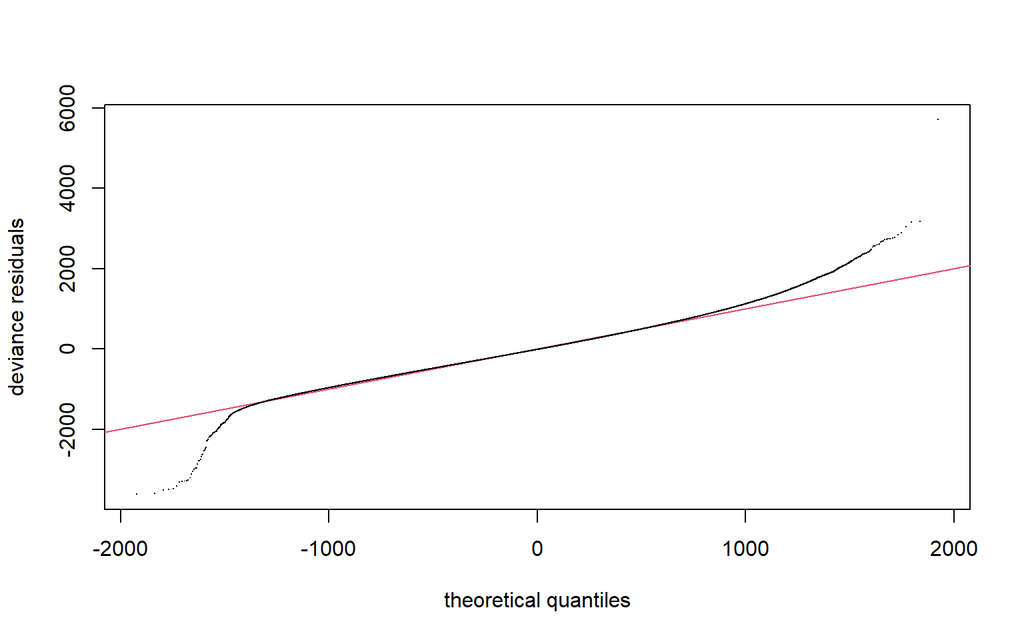

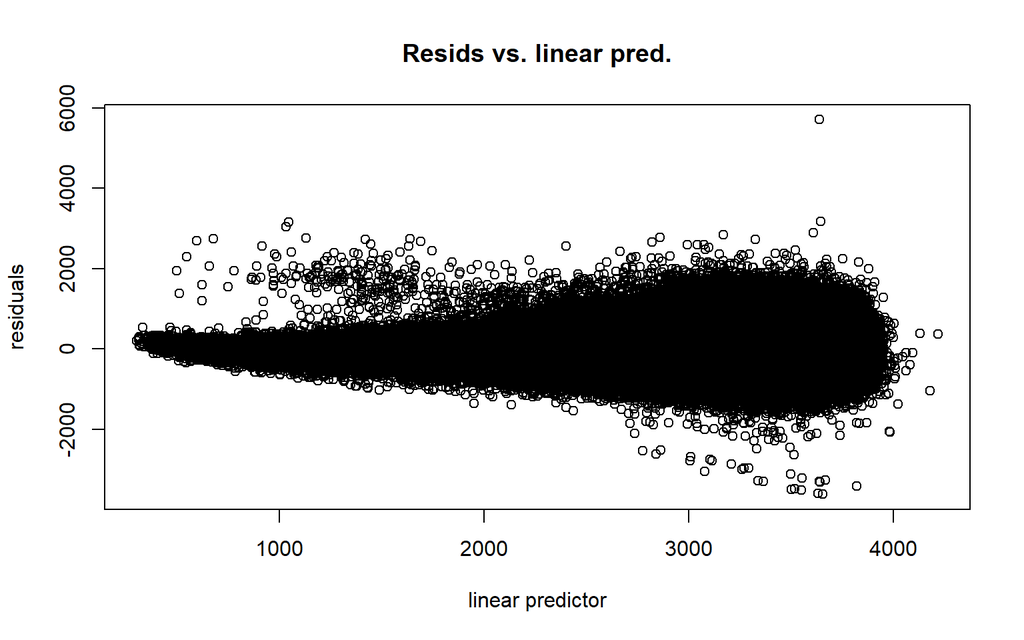

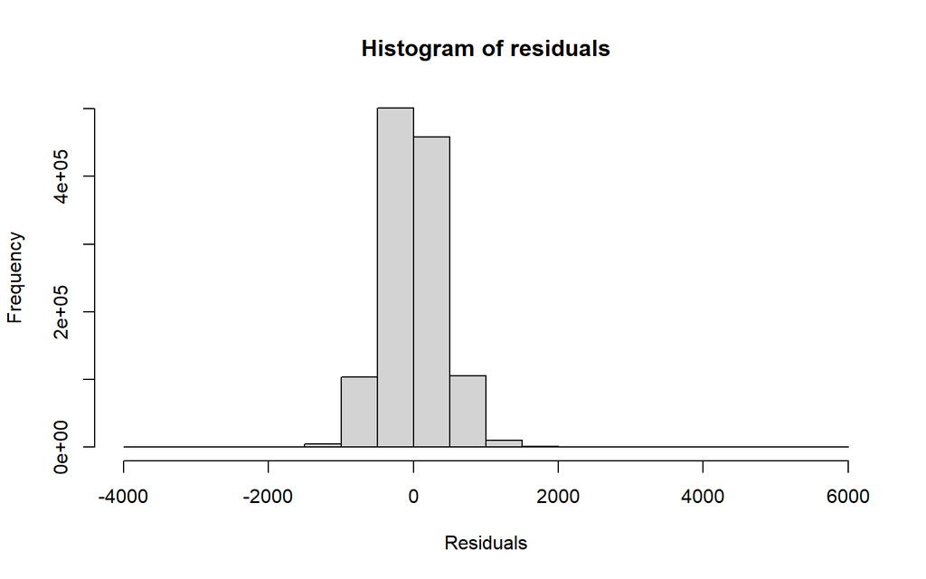

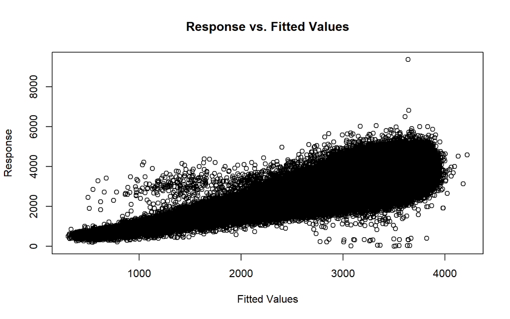

```
##
## Method: fREML   Optimizer: perf newton
## full convergence after 10 iterations.
## Gradient range [-0.02503489,0.01816981]
## (score 8751477 & scale 152379).
## Hessian positive definite, eigenvalue range [0.8792489,592423].
## Model rank =  71 / 71
##
## Basis dimension (k) checking results. Low p-value (k-index<1) may
## indicate that k is too low, especially if edf is close to k'.
##
##                     k'  edf k-index p-value
## s(GA_weeks)       9.00 8.88    1.00   0.545
## s(mat_age)        9.00 5.31    1.01   0.735
## s(birth_Y_M_num)  9.00 8.42    0.99   0.385
## s(month)          8.00 4.83    0.98   0.065 .
## s(mean_ssep2)     9.00 4.92    1.01   0.630
## s(mean_Alt_mean2) 9.00 7.16    1.02   0.850
## ---
## Signif. codes:  0 '***' 0.001 '**' 0.01 '*' 0.05 '.' 0.1 ' ' 1
```

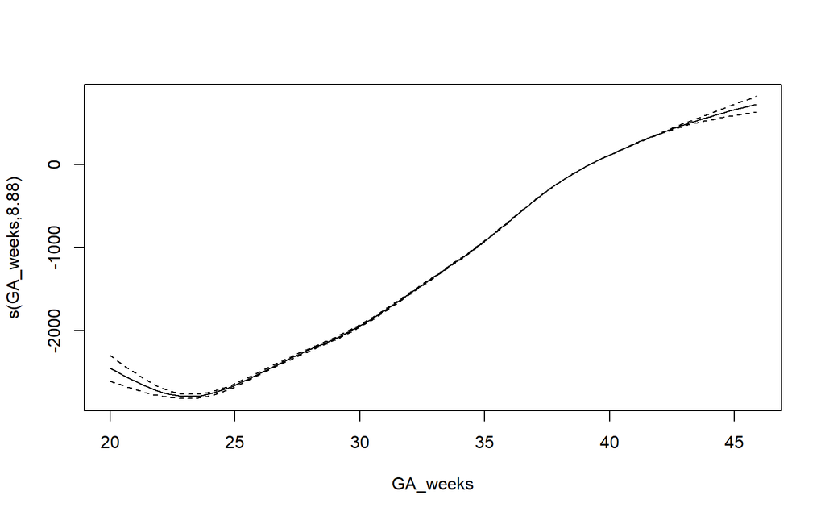

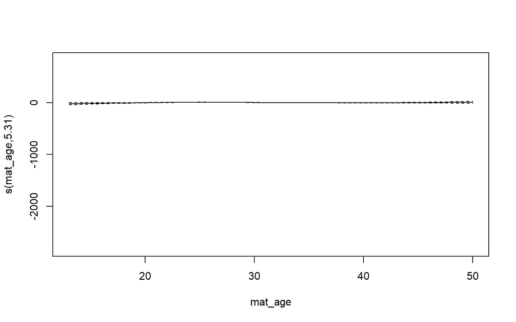

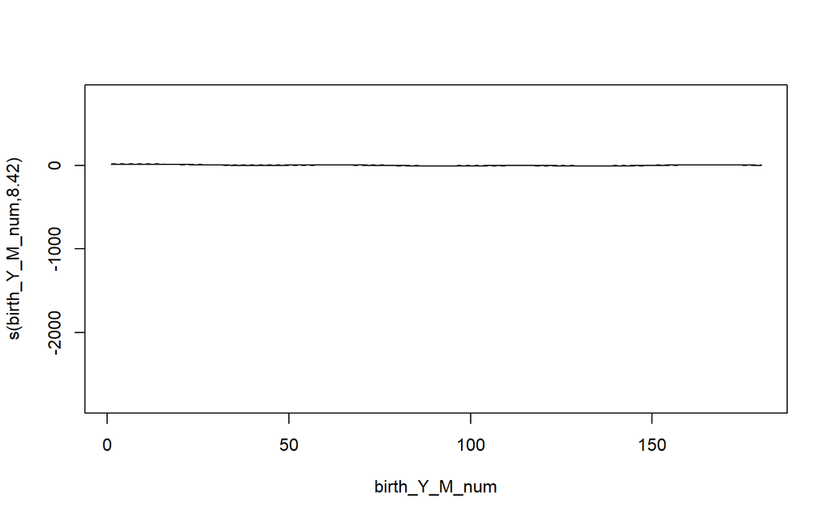

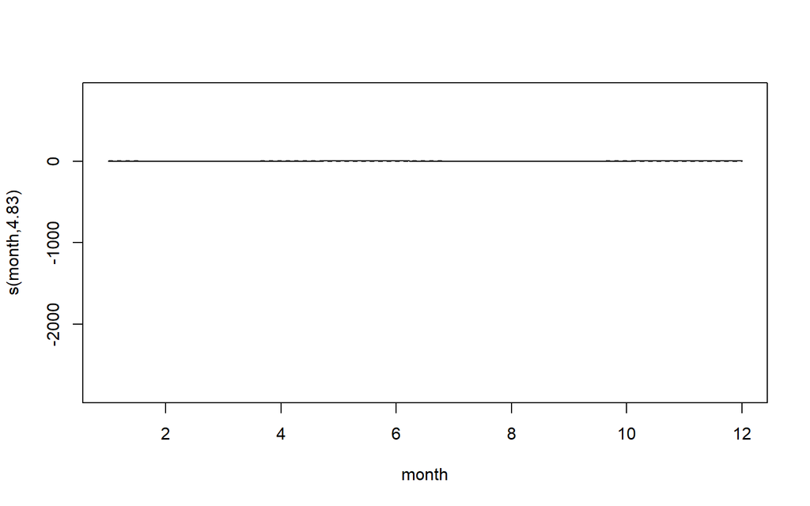

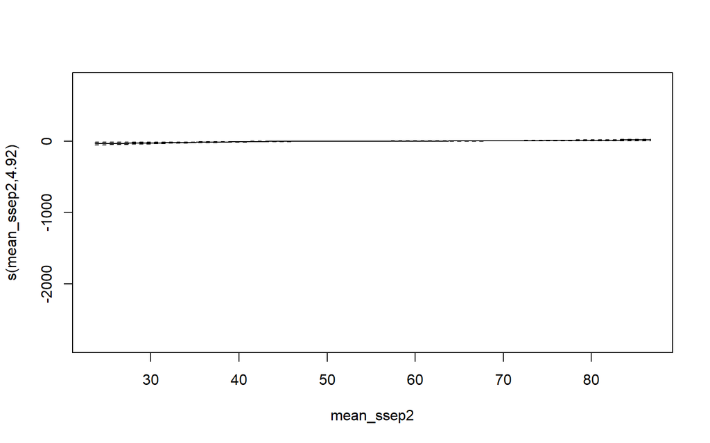

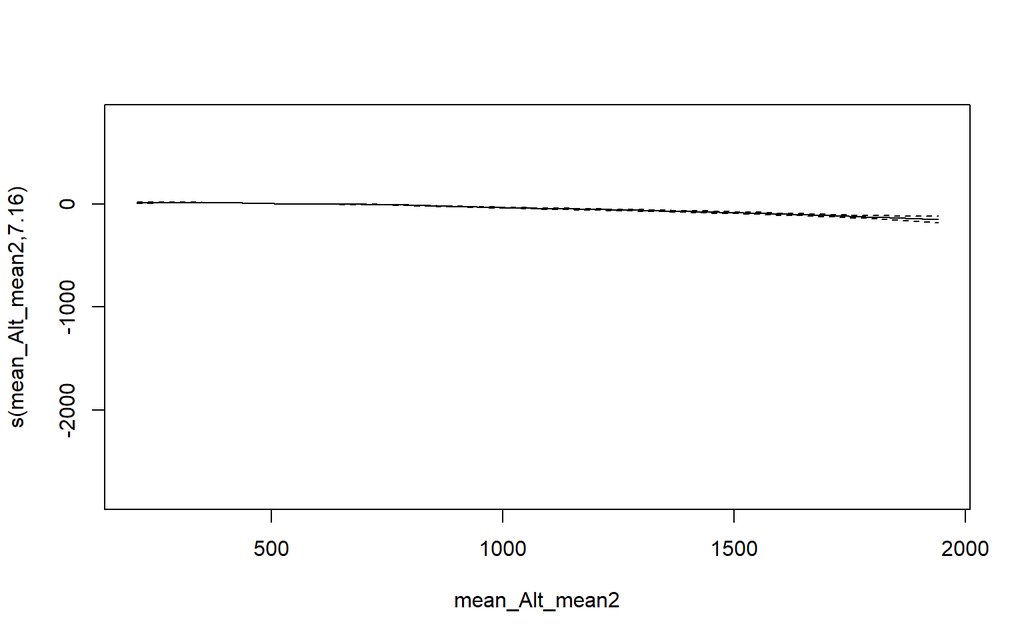

## Graph Gestational age X birthweight

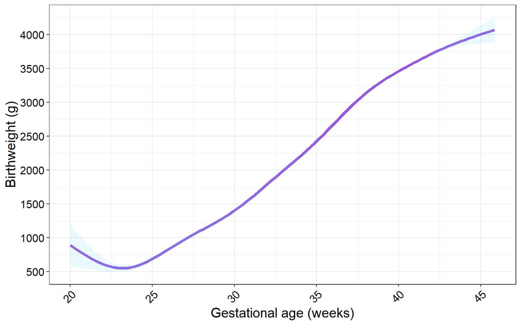

## Graph maternal age variable X BW

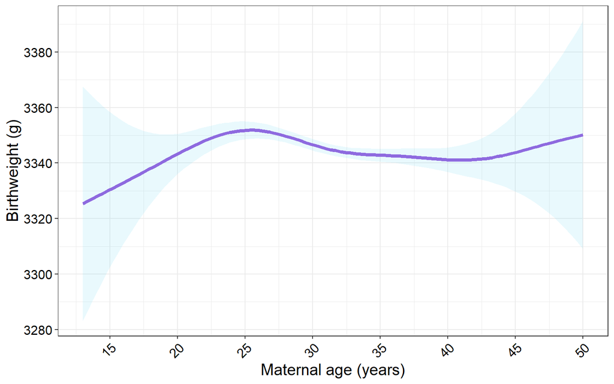

## Graph time X birthweight

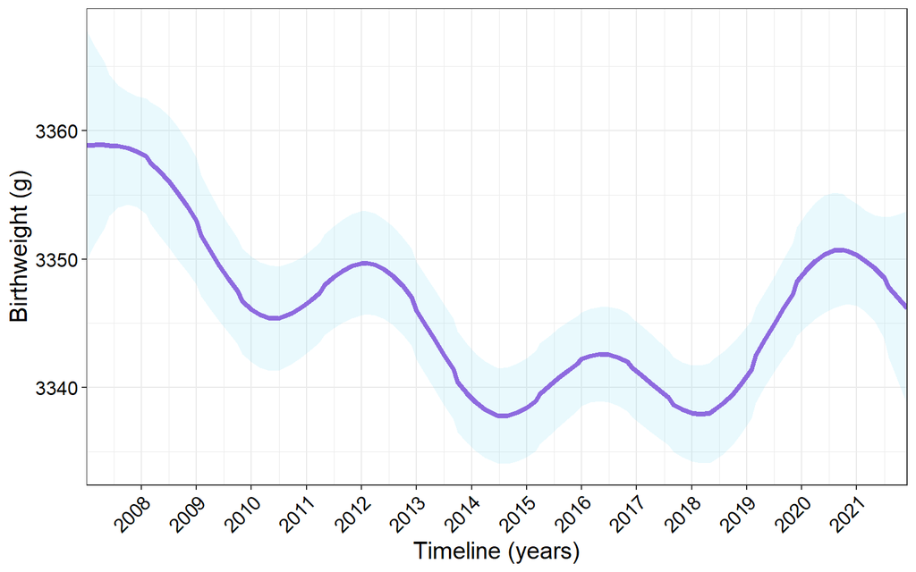

## Graph seasonality X birthweight

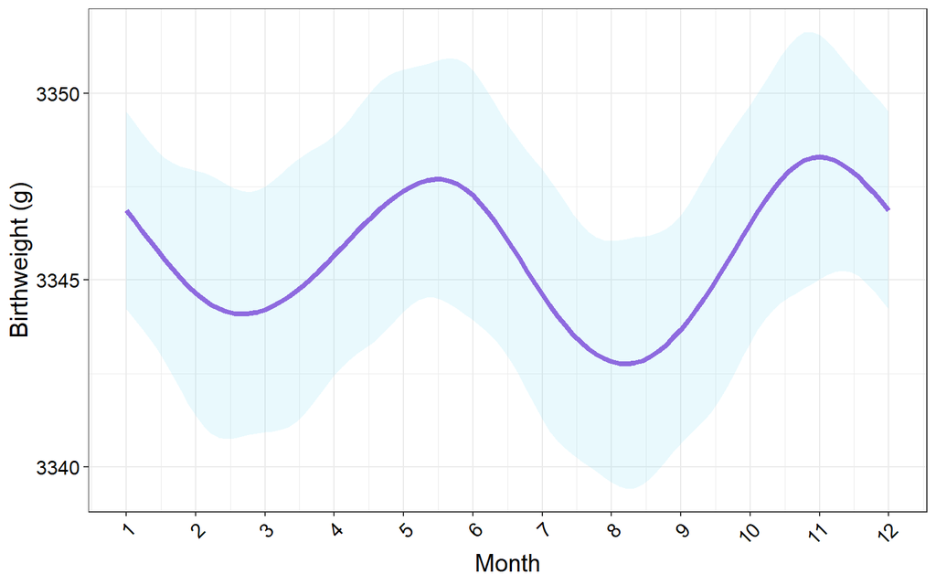

## Graph SSEP X birthweight

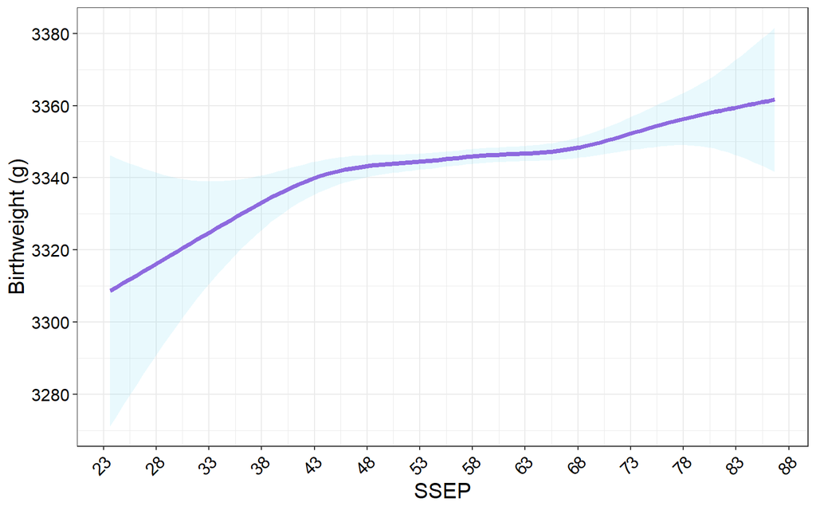

## Graph altitude X birthweight

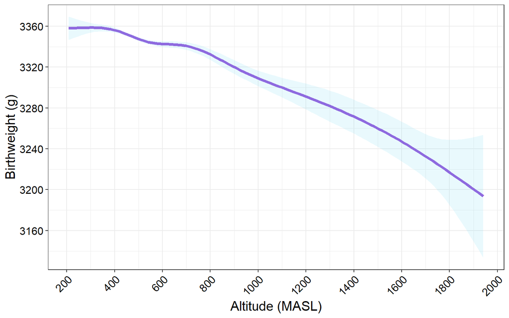

Cohen’s d formula:

$d=\frac{beta}{SD}$ and $SD=\sqrt{n}*se$

$d=\frac{beta}{\sqrt{n}*se}$

- beta: estimate
- se: standard error
- n: population/observation size
- SD: standard deviation

```
##                                                        beta     lci     uci    d
## (Intercept)                                         3345.71 3344.04 3347.38 3.75
## parity_cat(1,2]                                      123.23  121.64  124.82 0.14
## parity_cat(2,3]                                      167.87  165.45  170.30 0.13
## parity_cat(3,20]                                     193.79  189.60  197.98 0.09
## sex2                                                -146.87 -148.28 -145.46 0.20
## Urban3                                                -1.82   -3.34   -0.30 0.00
## LanguageFrench                                       -44.06  -45.84  -42.29 0.05
## LanguageItalian                                      -69.45  -73.53  -65.37 0.03
## mother_nationality_cat2Africa                          9.02    4.74   13.30 0.00
## mother_nationality_cat2Asia                          -25.48  -29.36  -21.59 0.01
## mother_nationality_cat2Europe                         28.80   27.19   30.42 0.03
## mother_nationality_cat2Northern America               58.61   49.40   67.83 0.01
## mother_nationality_cat2Southern and Central America   40.40   35.08   45.71 0.01
## civil_status3Single                                  -33.25  -35.01  -31.50 0.04
## HW1                                                   -2.79   -9.40    3.82 0.00
## GR1                                                    2.08   -2.88    7.04 0.00
## COVID_first_wave1                                     -1.82   -8.99    5.36 0.00
## COVID_second_wave1                                     3.02   -3.02    9.05 0.00
```

# Stillbirth

```
##
## Family: binomial
## Link function: logit
##
## Formula:
## stillbirth ~ s(GA_weeks) + s(mat_age) + s(birth_Y_M_num) + s(month,
##     bs = "cc") + s(mean_ssep2) + s(mean_Alt_mean2) + sex + Urban3 +
##     Language + mother_nationality_cat2 + civil_status3 + HW +
##     GR + COVID_first_wave + COVID_second_wave
##
## Parametric coefficients:
##                                                     Estimate Std. Error  z value
## (Intercept)                                         -7.02622    0.04450 -157.878
## sex2                                                 0.13601    0.03410    3.988
## Urban3                                               0.05312    0.03602    1.475
## LanguageFrench                                       0.10860    0.04067    2.670
## LanguageItalian                                     -0.03032    0.09966   -0.304
## mother_nationality_cat2Africa                        0.14599    0.08526    1.712
## mother_nationality_cat2Asia                         -0.05355    0.09256   -0.579
## mother_nationality_cat2Europe                        0.02082    0.03879    0.537
## mother_nationality_cat2Northern America             -0.36258    0.26325   -1.377
## mother_nationality_cat2Southern and Central America -0.15578    0.12536   -1.243
## civil_status3Single                                  0.03298    0.03901    0.845
## HW1                                                  0.06637    0.15065    0.441
## GR1                                                  0.16928    0.09805    1.727
## COVID_first_wave1                                   -0.11489    0.16947   -0.678
## COVID_second_wave1                                   0.05239    0.13635    0.384
##                                                     Pr(>|z|)
## (Intercept)                                          < 2e-16 ***
## sex2                                                6.66e-05 ***
## Urban3                                               0.14031
## LanguageFrench                                       0.00758 **
## LanguageItalian                                      0.76090
## mother_nationality_cat2Africa                        0.08684 .
## mother_nationality_cat2Asia                          0.56290
## mother_nationality_cat2Europe                        0.59139
## mother_nationality_cat2Northern America              0.16841
## mother_nationality_cat2Southern and Central America  0.21398
## civil_status3Single                                  0.39786
## HW1                                                  0.65952
## GR1                                                  0.08424 .
## COVID_first_wave1                                    0.49780
## COVID_second_wave1                                   0.70081
## ---
## Signif. codes:  0 '***' 0.001 '**' 0.01 '*' 0.05 '.' 0.1 ' ' 1
##
## Approximate significance of smooth terms:
##                     edf Ref.df    Chi.sq p-value
## s(GA_weeks)       8.000  8.513 23844.772 < 2e-16 ***
## s(mat_age)        3.172  3.993    10.588 0.03175 *
## s(birth_Y_M_num)  1.006  1.012     0.825 0.36749
## s(month)          1.830  8.000     6.660 0.01374 *
## s(mean_ssep2)     1.007  1.014     6.859 0.00918 **
## s(mean_Alt_mean2) 4.733  5.812    13.566 0.03128 *
## ---
## Signif. codes:  0 '***' 0.001 '**' 0.01 '*' 0.05 '.' 0.1 ' ' 1
##
## R-sq.(adj) =  0.224   Deviance explained = 40.4%
## fREML = 1.6903e+06  Scale est. = 1         n = 1189321
```

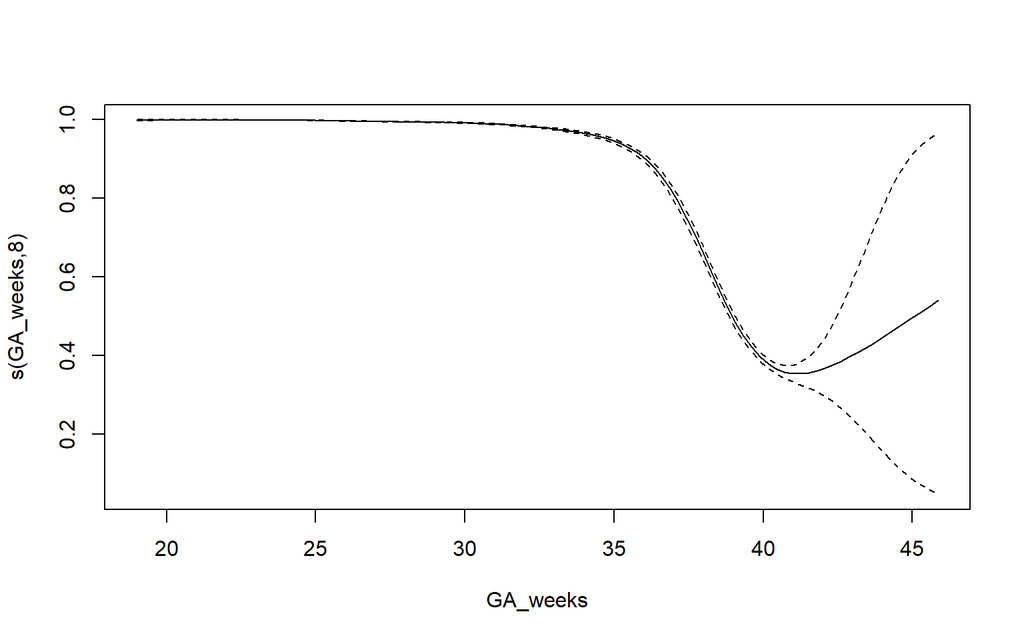

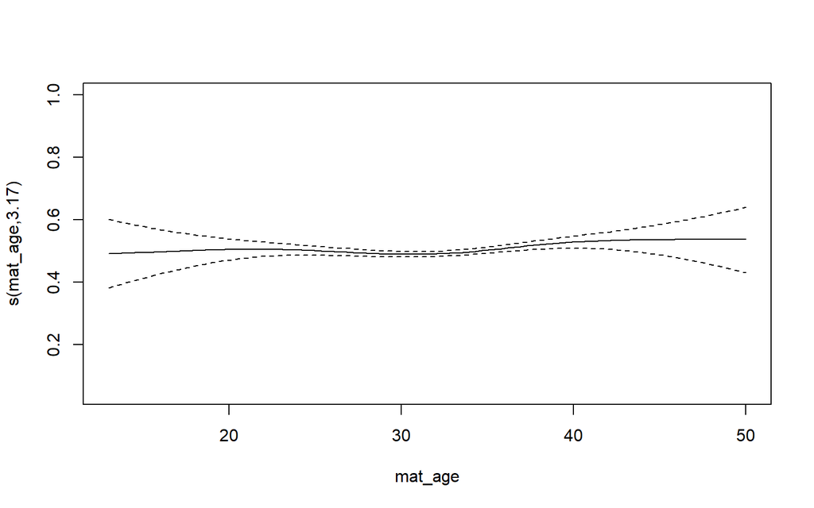

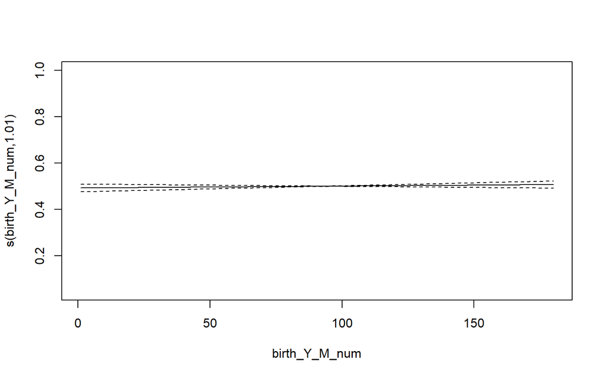

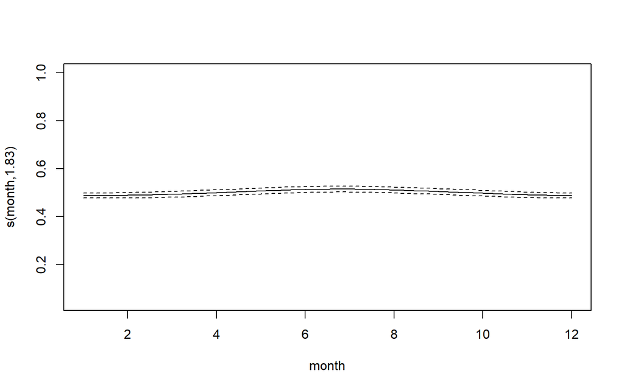

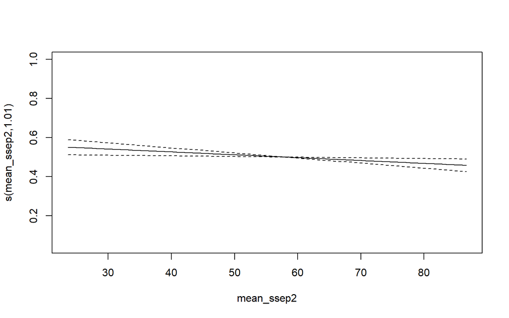

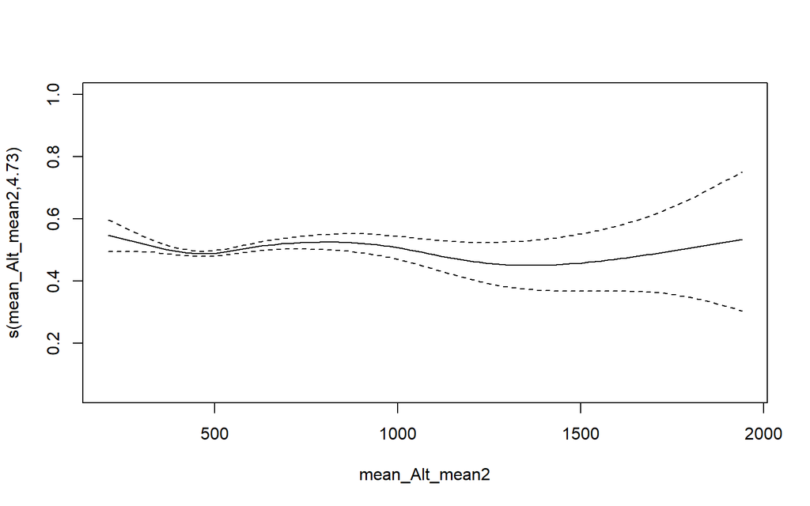

```
##                   k'      edf   k-index p-value
## s(GA_weeks)        9 8.000485 0.7936251  0.0000
## s(mat_age)         9 3.171589 0.9150718  0.4950
## s(birth_Y_M_num)   9 1.006089 0.9140072  0.4675
## s(month)           8 1.830071 0.9185824  0.7500
## s(mean_ssep2)      9 1.006809 0.9134847  0.4325
## s(mean_Alt_mean2)  9 4.732637 0.8996719  0.0375
```

```
##               para s(GA_weeks) s(mat_age) s(birth_Y_M_num)   s(month) s(mean_ssep2)
## worst    0.7586473 0.012229389 0.05788507        0.2984903 0.10235287     0.2686335
## observed 0.7586473 0.006019627 0.01871206        0.1316908 0.07905997     0.2223499
## estimate 0.7586473 0.008039119 0.04043099        0.1253303 0.03193102     0.1392811
##          s(mean_Alt_mean2)
## worst           0.23701200
## observed        0.06082784
## estimate        0.11261799
```

## Graph gestational age X Stillbirth

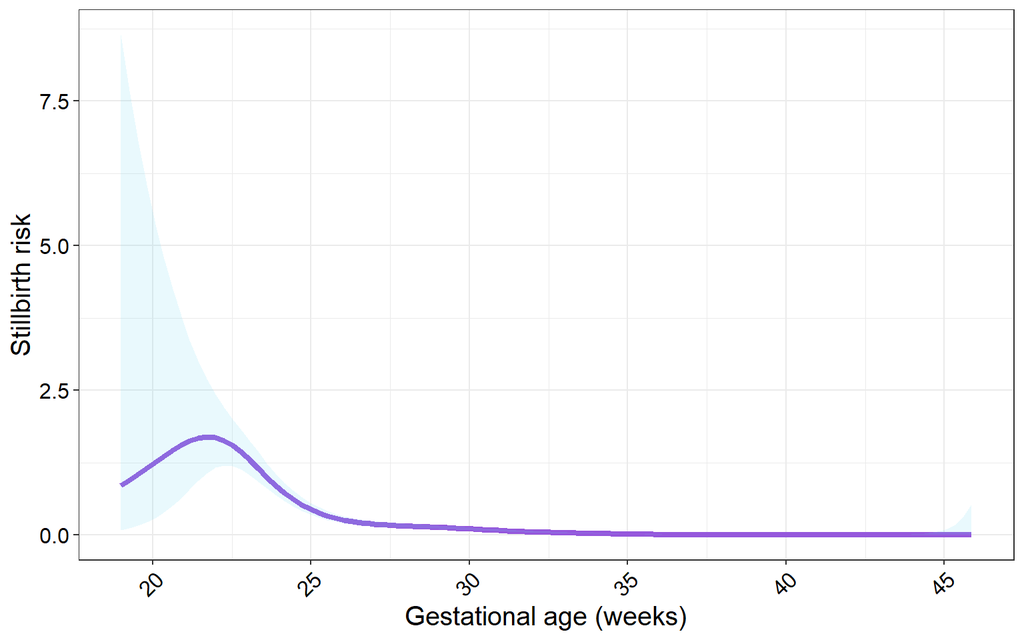

## Graph maternal age X Stillbirth

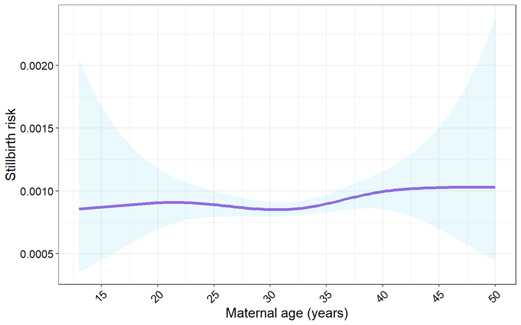

## Graph time X Stillbirth

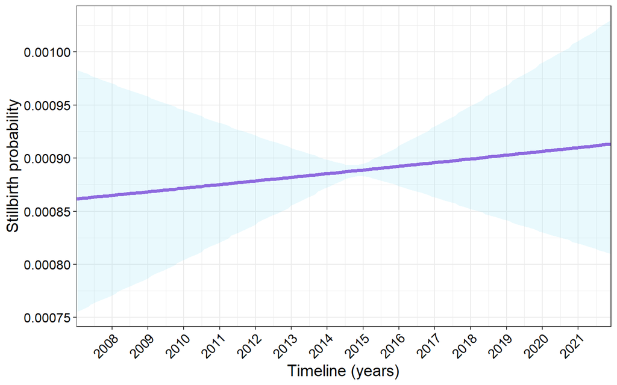

## Graph seasonality X Stillbirth

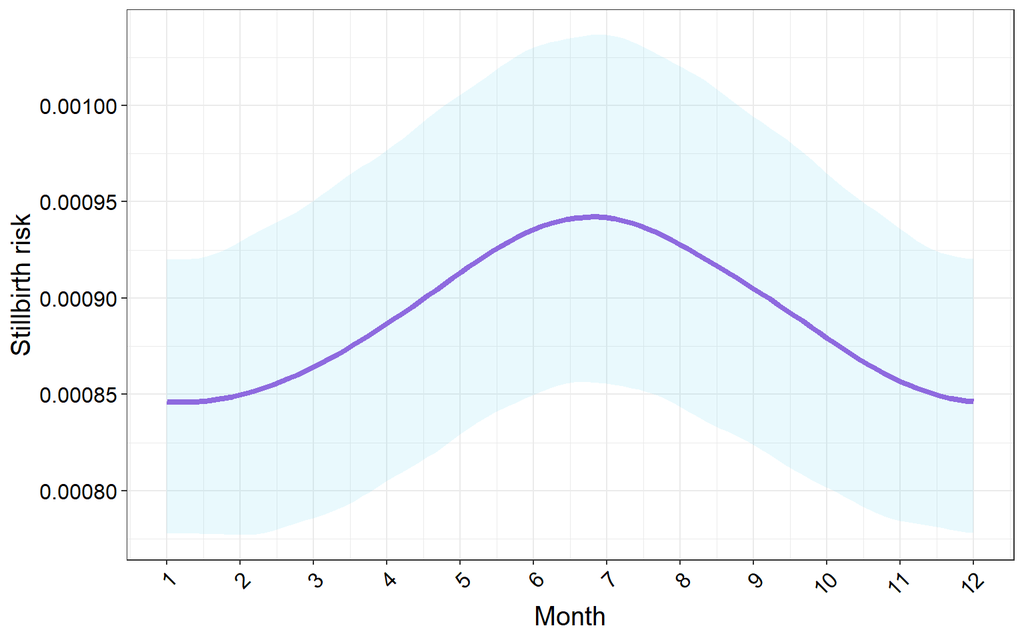

## Graph SSEP X Stillbirth

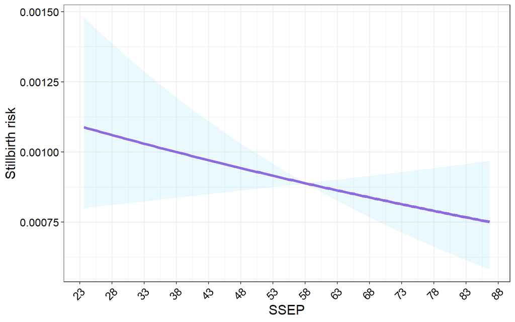

## Graph altitude X Stillbirth

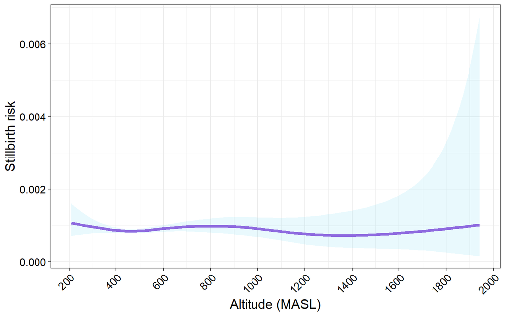

```
##                                                       OR  lci  uci    d
## (Intercept)                                         0.00 0.00 0.00 3.88
## sex2                                                1.15 1.07 1.22 0.08
## Urban3                                              1.05 0.98 1.13 0.03
## LanguageFrench                                      1.11 1.03 1.21 0.06
## LanguageItalian                                     0.97 0.80 1.18 0.02
## mother_nationality_cat2Africa                       1.16 0.98 1.37 0.08
## mother_nationality_cat2Asia                         0.95 0.79 1.14 0.03
## mother_nationality_cat2Europe                       1.02 0.95 1.10 0.01
## mother_nationality_cat2Northern America             0.70 0.42 1.17 0.20
## mother_nationality_cat2Southern and Central America 0.86 0.67 1.09 0.09
## civil_status3Single                                 1.03 0.96 1.12 0.02
## HW1                                                 1.07 0.79 1.44 0.04
## GR1                                                 1.18 0.98 1.44 0.09
## COVID_first_wave1                                   0.89 0.64 1.24 0.06
## COVID_second_wave1                                  1.05 0.81 1.38 0.03
```

Time variable (birth_Y_M_num) and mean ssep variable could have been put as linear terms, because the model including them as smoothed terms showed that the relationship between these and stillbirth was linear, but I chose to keep them as smooth variable to have models that look “more alike” between the different outcomes (birthweight, PTB).

# Preterm birth

```
##
## Family: binomial
## Link function: logit
##
## Formula:
## PTB ~ s(BW) + s(mat_age) + s(birth_Y_M_num) + s(month, bs = "cc") +
##     s(mean_ssep2) + s(mean_Alt_mean2) + parity_cat + sex + Urban3 +
##     Language + mother_nationality_cat2 + civil_status3 + HW +
##     GR + COVID_first_wave + COVID_second_wave
##
## Parametric coefficients:
##                                                     Estimate Std. Error  z value
## (Intercept)                                         -4.00574    0.01595 -251.072
## parity_cat(1,2]                                      0.10820    0.01206    8.972
## parity_cat(2,3]                                      0.22856    0.01879   12.165
## parity_cat(3,20]                                     0.40900    0.03111   13.148
## sex2                                                -0.70032    0.01069  -65.505
## Urban3                                              -0.05797    0.01124   -5.158
## LanguageFrench                                      -0.15136    0.01286  -11.769
## LanguageItalian                                     -0.22345    0.02878   -7.764
## mother_nationality_cat2Africa                       -0.14495    0.03475   -4.172
## mother_nationality_cat2Asia                         -0.14896    0.02861   -5.207
## mother_nationality_cat2Europe                        0.05040    0.01214    4.153
## mother_nationality_cat2Northern America              0.13773    0.07109    1.937
## mother_nationality_cat2Southern and Central America  0.19712    0.03783    5.211
## civil_status3Single                                 -0.09110    0.01275   -7.146
## HW1                                                  0.04726    0.04843    0.976
## GR1                                                  0.03997    0.03211    1.245
## COVID_first_wave1                                    0.02141    0.05299    0.404
## COVID_second_wave1                                  -0.05117    0.04494   -1.139
##                                                     Pr(>|z|)
## (Intercept)                                          < 2e-16 ***
## parity_cat(1,2]                                      < 2e-16 ***
## parity_cat(2,3]                                      < 2e-16 ***
## parity_cat(3,20]                                     < 2e-16 ***
## sex2                                                 < 2e-16 ***
## Urban3                                              2.50e-07 ***
## LanguageFrench                                       < 2e-16 ***
## LanguageItalian                                     8.20e-15 ***
## mother_nationality_cat2Africa                       3.02e-05 ***
```

[output cut: 10 more lines]

```
## Signif. codes:  0 '***' 0.001 '**' 0.01 '*' 0.05 '.' 0.1 ' ' 1
##
## Approximate significance of smooth terms:
##                     edf Ref.df    Chi.sq  p-value
## s(BW)             8.906  8.997 105359.78  < 2e-16 ***
## s(mat_age)        6.127  7.072    131.65  < 2e-16 ***
## s(birth_Y_M_num)  3.510  4.345     67.78  < 2e-16 ***
## s(month)          5.024  8.000     26.09 2.13e-05 ***
## s(mean_ssep2)     5.131  6.296     10.12    0.134
## s(mean_Alt_mean2) 2.365  3.009     65.96  < 2e-16 ***
## ---
## Signif. codes:  0 '***' 0.001 '**' 0.01 '*' 0.05 '.' 0.1 ' ' 1
##
## R-sq.(adj) =  0.386   Deviance explained = 43.7%
## fREML = 1.6985e+06  Scale est. = 1         n = 1184869
```

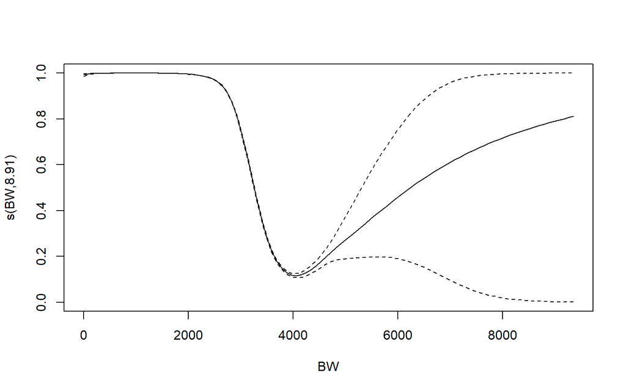

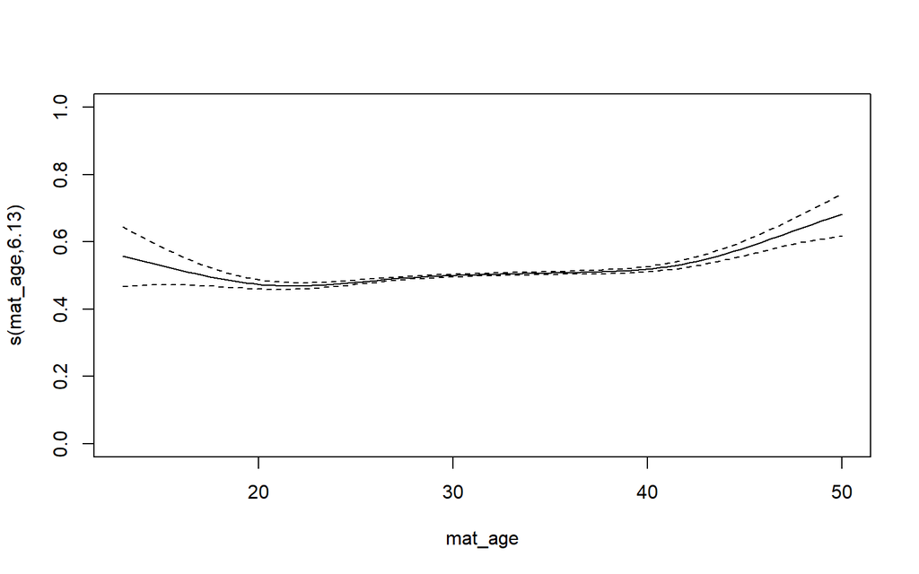